# Ejemplos Inferencia Estadística (I)

Edimer David Jaramillo

31 de mayo de 2018

# Ejemplo para $\mu$

Suponga que el proceso de llenado de bolsas de café con 500 gramos está operando correctanmente. Se toman aleatoriamente muestras de tamaño diez cada cuatro horas. Una muestra de bolsas está compuesta por las siguientes observacioness:

```r
muestra <- c(502, 501, 497, 491, 496, 501, 502, 500, 489, 490)
muestra
```

```
##  [1] 502 501 497 491 496 501 502 500 489 490
```

- Suponga que la muestra proviene de una distribución normal, ¿Está el proceso llenando bolsas conforme lo dice la envoltura?

**Solución:**

1. Planteamiento de hipótesis

$$H_0: \mu_{llenado}=500g$$
$$H_0: \mu_{llenado}\neq500g$$

2. Parámetro estimado

```r
(media_llenado <- mean(muestra))
```

```
## [1] 496.9
```

```r
(desviacion_llenado <- sd(muestra))
```

```
## [1] 5.173651
```

```r
tamaño_muestra <- 10
```

3. Validación de supuestos

Se asume que la muestra proviene de una distribución normal.

4. Nivel de significancia $\alpha$

$$\alpha=0.05$$

5. Obtener el valor P.

```r
t.test(x = muestra, mu = 500, conf.level = 0.95, alternative = "two.sided")
```

```
##
##  One Sample t-test
##
## data:  muestra
## t = -1.8948, df = 9, p-value = 0.09064
## alternative hypothesis: true mean is not equal to 500
## 95 percent confidence interval:
##  493.199 500.601
## sample estimates:
## mean of x
##     496.9
```

# Ejemplo para $\mu_1-\mu_2$

El conjunto de datos `births` del paquete `openintro` contiene información sobre 150 nacimientos junto con información de las madres. Se pretende saber si existen diferencias estadísticamente signifcativas para el peso promedio de los recien nacidos, entre madres fumadoras y no fumadoras.

**Solución:**

1. Planteamiento de hipótesis

$$H_0: \mu_{fuma}=\mu_{nofuma}$$
$$H_0: \mu_{fuma}\neq\mu_{nofuma}$$

2. Parámetro estimado

```r
births <- read.csv("Nacimientos.csv")
tapply(births$weight, births$smoke, mean)
```

```
## nonsmoker    smoker
##    7.1795    6.7790
```

```r
fuma <- 6.7790
nofuma <- 7.1795
(diferencia <- fuma - nofuma)
```

```
## [1] -0.4005
```

3. Validar supuestos
   - Normalidad

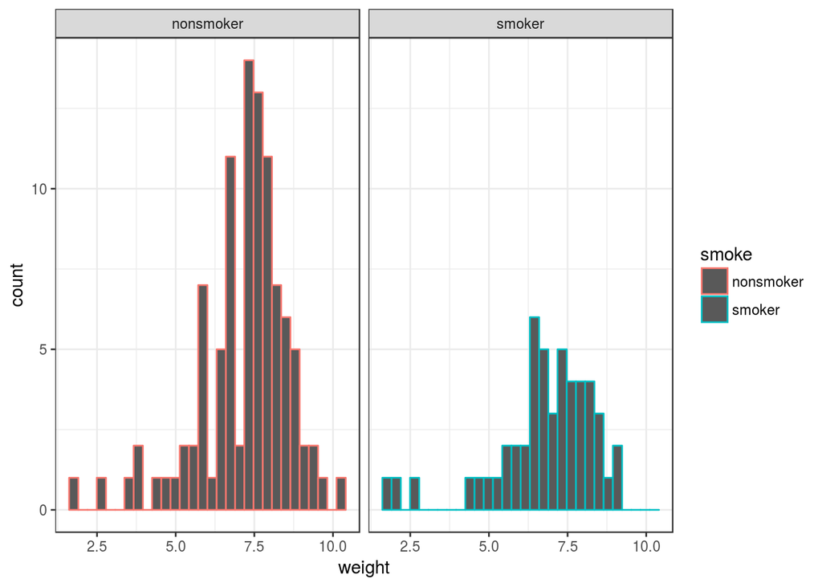

```r
library(ggplot2)
ggplot(births,aes(x = weight)) +
  geom_histogram(aes(colour = smoke)) +
  facet_grid(~ smoke) +
  theme_bw()
```

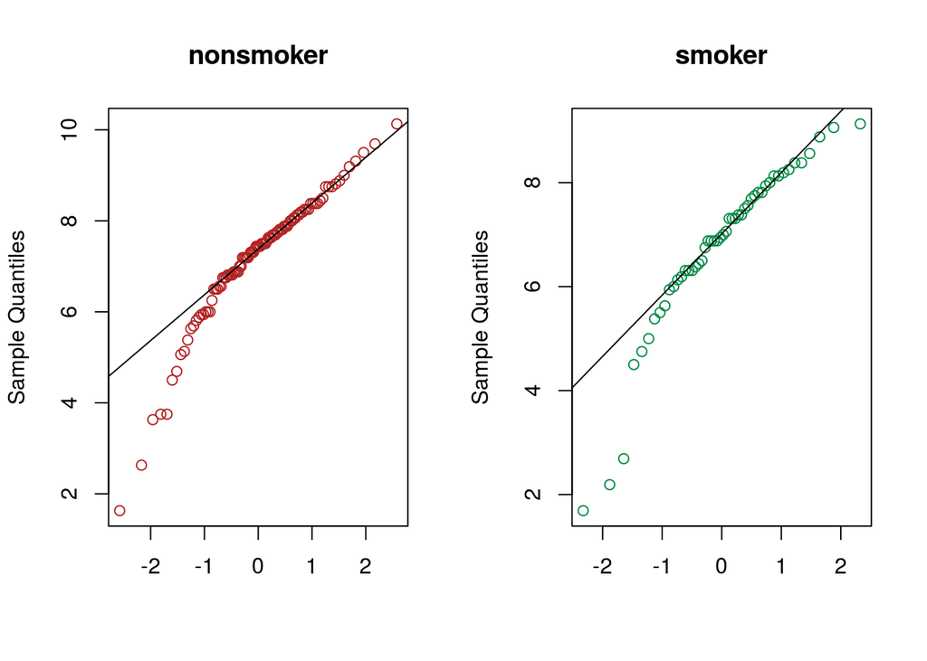

```r
par(mfrow = c(1, 2))
qqnorm(births[births$smoke == "nonsmoker","weight"], xlab = "",
       main = "nonsmoker", col = "firebrick")
qqline(births[births$smoke == "nonsmoker","weight"])
qqnorm(births[births$smoke == "smoker","weight"], xlab = "",
       main = "smoker", col = "springgreen4")
qqline(births[births$smoke == "smoker","weight"])
```

```r
shapiro.test(births[births$smoke == "smoker","weight"])
```

```
##
##  Shapiro-Wilk normality test
##
## data:  births[births$smoke == "smoker", "weight"]
## W = 0.89491, p-value = 0.0003276
```

```r
shapiro.test(births[births$smoke == "nonsmoker","weight"])
```

```
##
##  Shapiro-Wilk normality test
##
## data:  births[births$smoke == "nonsmoker", "weight"]
## W = 0.92374, p-value = 2.234e-05
```

- Homocedasticidad

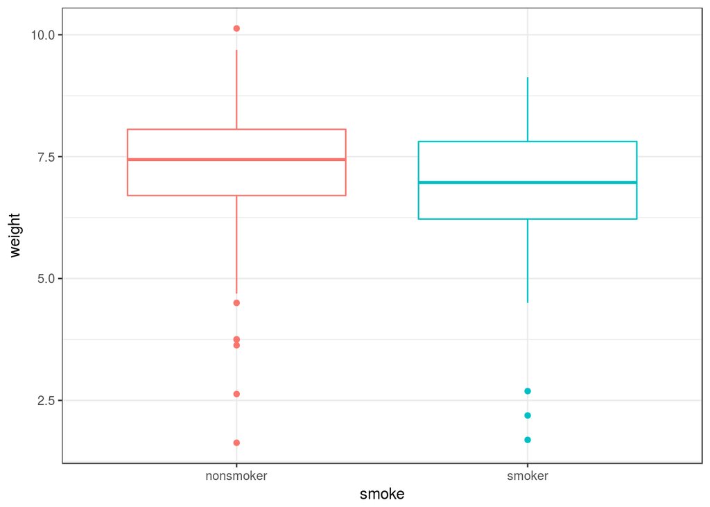

```r
ggplot(data = births) +
  geom_boxplot(aes(x = smoke, y = weight, colour = smoke)) +
  theme_bw() + theme(legend.position = "none")
```

```r
library(car)
leveneTest(weight ~ smoke, data = births, center = "median")
```

```
## Levene's Test for Homogeneity of Variance (center = "median")
##        Df F value Pr(>F)
## group   1  0.4442 0.5062
##       148
```

4. Nivel de significancia $\alpha$

$$\alpha=0.05$$

5. Obtener el valor P.

```r
t.test(x = births[births$smoke == "smoker", "weight"],
       y = births[births$smoke == "nonsmoker", "weight"],
       alternative = "two.sided", mu = 0, var.equal = TRUE, conf.level = 0.95)
```

```
##
##  Two Sample t-test
##
## data:  births[births$smoke == "smoker", "weight"] and births[births$smoke == "nonsmoker", "weight"]
## t = -1.5517, df = 148, p-value = 0.1229
## alternative hypothesis: true difference in means is not equal to 0
## 95 percent confidence interval:
##  -0.9105531  0.1095531
## sample estimates:
## mean of x mean of y
##    6.7790    7.1795
```

6. Conclusión

Dado que el valor P es igual a 0.1229 (mayor que 0.05), no existe evidencia suficiente para rechazar $H_0$, es decir, que el peso promedio de los recien nacidos con madres que fuman, no difiere de aquellos cuyas madre sí lo hacen. En otras palabras, no existe suficiente evidencia para decir que los promedios de peso de los recien nacidos son diferentes.

# Ejemplo para $\sigma^2_1/\sigma^2_2$

En la base de datos `CO2` que contiene R, se registran datos para el consumo de dioxido de carbono en plantas de *Echinochloa crus galli*. Se quiere saber si las varianzas del consumo discrepan dado el origen de la planta.

**Solución:**

1. Planteamiento de hipótesis

$$H_0: \sigma^2_{Mississipi}=\sigma^2_{Quebec}$$
$$H_0: \sigma^2_{Mississipi}\neq\sigma^2_{Quebec}$$

2. Parámetro estimado

```r
tapply(CO2$uptake, CO2$Type, var)
```

```
##      Quebec Mississippi
##     93.5830     61.0863
```

3. Validar supuestos
   - Normalidad

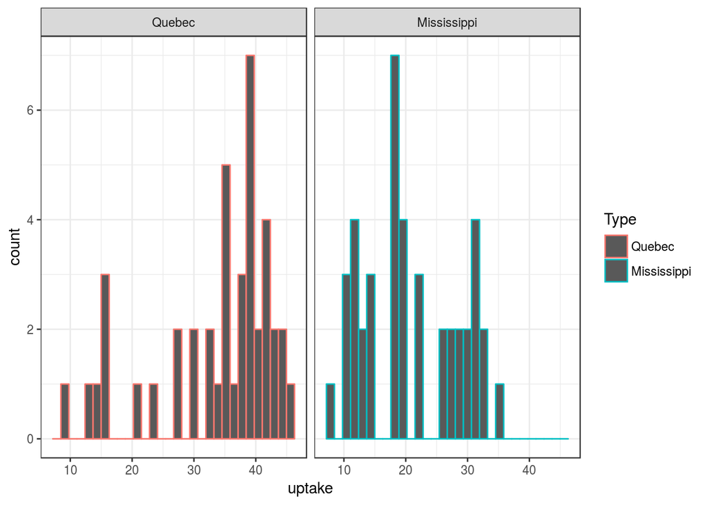

```r
library(ggplot2)
ggplot(CO2, aes(x = uptake)) +
  geom_histogram(aes(colour = Type)) +
  facet_grid(~ Type) +
  theme_bw()
```

4. Nivel de significancia $\alpha$

$$\alpha=0.05$$

5. Obtener el valor P.

```r
mississipi <- CO2[CO2$Type == "Mississippi",]
Quebec <- CO2[CO2$Type == "Quebec",]
var.test(x = mississipi$uptake,
         y = Quebec$uptake, alternative = "two.sided", conf.level = 0.95,
         ratio = 1)
```

```
##
##  F test to compare two variances
##
## data:  mississipi$uptake and Quebec$uptake
## F = 0.65275, num df = 41, denom df = 41, p-value = 0.1763
## alternative hypothesis: true ratio of variances is not equal to 1
## 95 percent confidence interval:
##  0.3508686 1.2143652
## sample estimates:
## ratio of variances
##            0.65275
```

6. Conclusión

Dado que el valor P es igual a 0.1763 (mayor que NS de 0.05), no existe evidencia suficiente para rechazar $H_0$, es decir, que la varianza del consumo de dioxido de carbono es igual entre plantas de ambos tipos de origen.